# Case Study 3: Flagging Spam Emails

#### Team: Ana Glaser, Jake Harrison, Rob Burigo, and Yvan Sojdehei

## Business Understanding

The company in question has workers recieving vast amounts of emails every day. The objective of this Case Study is to classify whether or not an email is spam or work-related to streamline inboxes to only include the important emails.

## Modeling Preparations

#### Methods:

The methods our team applied to solve this problem include Naive Bayes and K-Means Clustering. In preparation for the modeling, the team partitioned each email segment from the email file into a structured form. Then various natural language processing cleansing techniques were implemented to conduct the exploratory data analysis. Due to the unique nature of the input data, an email file, this approach seemed appropriate to feature engineer the enriched data available within the file structure.

#### Evaluation Metrics:

The metrics our team utilized for this project include F-1 Score and the Confusion Matrix for the Naive Bayes.

Initially we intended to use Accuracy and Precision, but due to the imbalanced nature of the data we pivoted towards F1 Score.

The main reason our team chose to use these metrics is because they evaluate the model performance better with disproportionate classifications that exist within our dataset. F1 is a calculation of recall and precision which represents a more holisitic view of the success of our Naive Bayes model.

#### Importing Packages

```python
import os
import pandas as pd
import numpy as np
from email.parser import BytesParser, Parser
from email.policy import default
import email
from html.parser import HTMLParser
from bs4 import BeautifulSoup
from collections import Counter
import re
import plotly.express as px
import nltk
import seaborn as sns
nltk.download('stopwords')
nltk.download('punkt')
nltk.download('wordnet')
nltk.download('omw-1.4')
from sklearn.naive_bayes import MultinomialNB

from sklearn.model_selection import train_test_split
from sklearn.cluster import KMeans
import statsmodels.api as sm
from sklearn.metrics import precision_score, recall_score, f1_score, accuracy_score

from nltk.corpus import stopwords
from nltk.tokenize import word_tokenize, sent_tokenize
from nltk.stem.wordnet import WordNetLemmatizer

from sklearn.feature_extraction.text import CountVectorizer
from sklearn.model_selection import train_test_split

from sklearn.ensemble import RandomForestClassifier
from sklearn.model_selection import cross_val_score

import matplotlib.pyplot as plt
import seaborn as sns
from sklearn.metrics import confusion_matrix
from yellowbrick.model_selection import FeatureImportances

from sklearn.feature_extraction.text import TfidfVectorizer

import warnings
warnings.filterwarnings('ignore')
```

#### Defining Functions to use within the Feature Engineering section.

```python
def strip_html(text):
    soup = BeautifulSoup(text,"html.parser")
    return soup.get_text()


def to_lowercase(words):
    """Convert all characters to lowercase from list of tokenized words"""
    new_words = []
    for word in words:
        new_word = word.lower()
        new_words.append(new_word)
    return new_words

def remove_punctuation(words):
    """Remove punctuation from list of tokenized words"""
    new_words = []
    for word in words:
        new_word = re.sub(r'[^\w\s]', '', word)
        if new_word != '':
            new_words.append(new_word)
    return new_words

def remove_stopwords(words):
    """Remove stop words from list of tokenized words"""
    new_words = []
    for word in words:
        if word not in stop_list:
            new_words.append(word)
    return new_words

def lemmatize_list(words):
    lemmatizer = WordNetLemmatizer()
    new_words = []
    for word in words:
        new_words.append(lemmatizer.lemmatize(word, pos='v'))
    return new_words

def normalize(words):
    words = to_lowercase(words)
    words = remove_punctuation(words)
    words = remove_stopwords(words)
    words = lemmatize_list(words)
    return ' '.join(words)

stop_words = stopwords.words('english')

customlist = ['not', "couldn't", 'didn', "didn't", 'doesn', "doesn't", 'hadn', "hadn't", 'hasn',
        "hasn't", 'haven', "haven't", 'isn', "isn't", 'ma', 'mightn', "mightn't", 'mustn',
        "mustn't", 'needn', "needn't", 'shan', "shan't", 'shouldn', "shouldn't", 'wasn',
        "wasn't", 'weren', "weren't", 'won', "won't", 'wouldn', "wouldn't"]

stop_list = list(set(stop_words) - set(customlist))
```

## Data Evaluation / Engineering

#### Importing Data. We consolidated all email file directories into a ham and nonspam folder for ease of processing.

```python
spam_list = os.listdir("./spam/")
ham_list = os.listdir("./easy_ham/")
```

#### First Iteration is to clean and combine the non spam email file headers with its content.

```python
folder=("./easy_ham")
files=os.listdir(folder)
emails=[folder+'/'+file for file in files]
```

```python
dataStackText = pd.DataFrame()
my_dict_text = {"Words":[], "Type":[]}

words=[]
for email in emails:
    f = open(email, encoding='latin-1')
    blob = f.read()
    my_dict_text["Words"].append(blob)
    my_dict_text['Type'].append(0)
dataStackText = pd.DataFrame(my_dict_text)
```

```python
dataStack = pd.DataFrame()
my_dict = {"To":[], "From":[], "Subject":[]}

for i in ham_list:
    with open("./easy_ham/"+i, 'rb') as fp:
        try:
            headers = BytesParser(policy=default).parse(fp)
            to_text = '{}'.format(headers['to'])
            from_text = '{}'.format(headers['from'])
            subject = '{}'.format(headers['subject'])
            my_dict["To"].append(to_text)
            my_dict["From"].append(from_text)
            my_dict["Subject"].append(subject)
        except Exception:
            continue

dataStack = pd.DataFrame(my_dict)
```

```python
EMAIL_DF = pd.merge(dataStack,dataStackText, how='left',left_index = True, right_index = True)
```

```python
COMPLETE_EMAIL_DF = EMAIL_DF
COMPLETE_EMAIL_DF.shape
```

```
(6940, 5)
```

#### Second Iteration is to clean and combine the spam email file headers with its content.

```python
folder=("./spam")
files=os.listdir(folder)
emails=[folder+'/'+file for file in files]
```

```python
dataStackText = pd.DataFrame()
my_dict_text = {"Words":[], "Type":[]}

words=[]
for email in emails:
    f = open(email, encoding='latin-1')
    blob = f.read()
    my_dict_text["Words"].append(blob)
    my_dict_text['Type'].append(1)
dataStackText = pd.DataFrame(my_dict_text)
```

```python
dataStack = pd.DataFrame()
my_dict = {"To":[], "From":[], "Subject":[]}

for i in spam_list:
    with open("./spam/"+i, 'rb') as fp:
        try:
            headers = BytesParser(policy=default).parse(fp)
            #print(headers)
            to_text = '{}'.format(headers['to'])
            from_text = '{}'.format(headers['from'])
            subject = '{}'.format(headers['subject'])
            my_dict["To"].append(to_text)
            my_dict["From"].append(from_text)
            my_dict["Subject"].append(subject)
        except Exception:
            continue

dataStack = pd.DataFrame(my_dict)
```

#### We stacked the nonspam and spam datasets together to create one dataframe to analyze.

```python
EMAIL_DF = pd.merge(dataStack,dataStackText, how='left',left_index = True, right_index = True)
```

```python
COMPLETE_EMAIL_DF = COMPLETE_EMAIL_DF.append(EMAIL_DF)
COMPLETE_EMAIL_DF.shape
```

```
(9338, 5)
```

```python
COMPLETE_EMAIL_DF.head()
```

|  | To | From | Subject | Words | Type |
| --- | --- | --- | --- | --- | --- |
| 0 | Chris Garrigues <cwg-dated-1030314468.7c7c85@D... | Robert Elz <kre@munnari.OZ.AU> | Re: New Sequences Window | Return-Path: <exmh-workers-admin@spamassassin.... | 0 |
| 1 | mkettler@home.com | The Motley Fool <Fool@motleyfool.com> | Personal Finance: Resolutions You Can Keep | Return-Path: Fool@motleyfool.com\nDelivery-Dat... | 0 |
| 2 | Valdis.Kletnieks@vt.edu | Chris Garrigues <cwg-exmh@DeepEddy.Com> | Re: New Sequences Window | From exmh-workers-admin@redhat.com Wed Aug 21... | 0 |
| 3 | rod-3ds@arsecandle.org | malcolm-sweeps@mrichi.com | Malcolm in the Middle Sweepstakes Prize Notifi... | Return-Path: <malcolm-sweeps@mrichi.com>\nDeli... | 0 |
| 4 | Robert Elz <kre@munnari.OZ.AU> | Chris Garrigues <cwg-exmh@DeepEddy.Com> | Re: New Sequences Window | From exmh-workers-admin@redhat.com Wed Aug 21... | 0 |

#### Normalized the data for analysis using standard Natural Language Processing data cleansing techniques such as stripping html, removing punctuation, stop words, and made everything lowercase.

```python
# Removing any excess html
COMPLETE_EMAIL_DF['Words'] = COMPLETE_EMAIL_DF['Words'].apply(lambda x: strip_html(x))
COMPLETE_EMAIL_DF['Subject'] = COMPLETE_EMAIL_DF['Subject'].apply(lambda x: strip_html(x))
```

```python
# Tokenizing each column
COMPLETE_EMAIL_DF['Words_norm'] = COMPLETE_EMAIL_DF.apply(lambda row: nltk.word_tokenize(row['Words']), axis=1)
COMPLETE_EMAIL_DF['Subject_norm'] = COMPLETE_EMAIL_DF.apply(lambda row: nltk.word_tokenize(row['Subject']), axis=1)
COMPLETE_EMAIL_DF['To_norm'] = COMPLETE_EMAIL_DF.apply(lambda row: nltk.word_tokenize(row['To']), axis=1)
COMPLETE_EMAIL_DF['From_norm'] = COMPLETE_EMAIL_DF.apply(lambda row: nltk.word_tokenize(row['From']), axis=1)
```

```python
# normalizing each column

COMPLETE_EMAIL_DF['Subject_norm'] = COMPLETE_EMAIL_DF.apply(lambda row: normalize(row['Subject_norm']), axis=1)
COMPLETE_EMAIL_DF['Words_norm'] = COMPLETE_EMAIL_DF.apply(lambda row: normalize(row['Words_norm']), axis=1)
COMPLETE_EMAIL_DF['To_norm'] = COMPLETE_EMAIL_DF.apply(lambda row: normalize(row['To_norm']), axis=1)
COMPLETE_EMAIL_DF['From_norm'] = COMPLETE_EMAIL_DF.apply(lambda row: normalize(row['From_norm']), axis=1)
```

```python
COMPLETE_EMAIL_DF.head()
```

|  | To | From | Subject | Words | Type | Words_norm | Subject_norm | To_norm | From_norm |
| --- | --- | --- | --- | --- | --- | --- | --- | --- | --- |
| 0 | Chris Garrigues <cwg-dated-1030314468.7c7c85@D... | Robert Elz <kre@munnari.OZ.AU> | Re: New Sequences Window | Return-Path: \nDelivered-To: yyyy@localhost.ne... | 0 | returnpath deliveredto yyyy localhostnetnotein... | new sequence window | chris garrigues cwgdated10303144687c7c85 deepe... | robert elz kre munnariozau |
| 1 | mkettler@home.com | The Motley Fool <Fool@motleyfool.com> | Personal Finance: Resolutions You Can Keep | Return-Path: Fool@motleyfool.com\nDelivery-Dat... | 0 | returnpath fool motleyfoolcom deliverydate wed... | personal finance resolutions keep | mkettler homecom | motley fool fool motleyfoolcom |
| 2 | Valdis.Kletnieks@vt.edu | Chris Garrigues <cwg-exmh@DeepEddy.Com> | Re: New Sequences Window | From exmh-workers-admin@redhat.com Wed Aug 21... | 0 | exmhworkersadmin redhatcom wed aug 21 161835 2... | new sequence window | valdiskletnieks vtedu | chris garrigues cwgexmh deepeddycom |
| 3 | rod-3ds@arsecandle.org | malcolm-sweeps@mrichi.com | Malcolm in the Middle Sweepstakes Prize Notifi... | Return-Path: \nDelivered-To: rod@arsecandle.or... | 0 | returnpath deliveredto rod arsecandleorg recei... | malcolm middle sweepstakes prize notification | rod3ds arsecandleorg | malcolmsweeps mrichicom |
| 4 | Robert Elz <kre@munnari.OZ.AU> | Chris Garrigues <cwg-exmh@DeepEddy.Com> | Re: New Sequences Window | From exmh-workers-admin@redhat.com Wed Aug 21... | 0 | exmhworkersadmin redhatcom wed aug 21 161836 2... | new sequence window | robert elz kre munnariozau | chris garrigues cwgexmh deepeddycom |

#### Created a list of most common spam words to leverage in the feature engineering functions.

```python
folder=("./spam")
files=os.listdir(folder)
emails=[folder+'/'+file for file in files]
```

```python
words=[]
for email in emails:
    f = open(email, encoding='latin-1')
    blob = f.read()
    words += blob.split(" ")
words = to_lowercase(words)
words = remove_stopwords(words)
```

```python
for i in range(len(words)):
    if not words[i].isalpha():
        words[i]=""
word_dict = Counter(words)
del word_dict[""]
```

```python
word_dict = word_dict.most_common(1000)
word_dict = [k for k,v in word_dict]
```

#### Now we have a dataframe that contains a series of the original and normalized email content.

```python
COMPLETE_EMAIL_DF.head()
```

|  | To | From | Subject | Words | Type | Words_norm | Subject_norm | To_norm | From_norm |
| --- | --- | --- | --- | --- | --- | --- | --- | --- | --- |
| 0 | Chris Garrigues <cwg-dated-1030314468.7c7c85@D... | Robert Elz <kre@munnari.OZ.AU> | Re: New Sequences Window | Return-Path: \nDelivered-To: yyyy@localhost.ne... | 0 | returnpath deliveredto yyyy localhostnetnotein... | new sequence window | chris garrigues cwgdated10303144687c7c85 deepe... | robert elz kre munnariozau |
| 1 | mkettler@home.com | The Motley Fool <Fool@motleyfool.com> | Personal Finance: Resolutions You Can Keep | Return-Path: Fool@motleyfool.com\nDelivery-Dat... | 0 | returnpath fool motleyfoolcom deliverydate wed... | personal finance resolutions keep | mkettler homecom | motley fool fool motleyfoolcom |
| 2 | Valdis.Kletnieks@vt.edu | Chris Garrigues <cwg-exmh@DeepEddy.Com> | Re: New Sequences Window | From exmh-workers-admin@redhat.com Wed Aug 21... | 0 | exmhworkersadmin redhatcom wed aug 21 161835 2... | new sequence window | valdiskletnieks vtedu | chris garrigues cwgexmh deepeddycom |
| 3 | rod-3ds@arsecandle.org | malcolm-sweeps@mrichi.com | Malcolm in the Middle Sweepstakes Prize Notifi... | Return-Path: \nDelivered-To: rod@arsecandle.or... | 0 | returnpath deliveredto rod arsecandleorg recei... | malcolm middle sweepstakes prize notification | rod3ds arsecandleorg | malcolmsweeps mrichicom |
| 4 | Robert Elz <kre@munnari.OZ.AU> | Chris Garrigues <cwg-exmh@DeepEddy.Com> | Re: New Sequences Window | From exmh-workers-admin@redhat.com Wed Aug 21... | 0 | exmhworkersadmin redhatcom wed aug 21 161836 2... | new sequence window | robert elz kre munnariozau | chris garrigues cwgexmh deepeddycom |

### Feature Engineering:

#### As part of the analysis, we appended a series of data characteristics based on spam emails' key word frequency.

#### Passing most common spam words and getting a count for each email's subject and content.

```python
spam_list_words = word_dict
COMPLETE_EMAIL_DF['spam_count_content'] = COMPLETE_EMAIL_DF['Words_norm'].apply(lambda x: sum(i in spam_list_words for i in x.split()))
COMPLETE_EMAIL_DF['spam_count_subject'] = COMPLETE_EMAIL_DF['Subject_norm'].apply(lambda x: sum(i in spam_list_words for i in x.split()))
```

#### Getting a capital letter count for each email's from, subject, and content.

```python
COMPLETE_EMAIL_DF['subject_cl_count'] = COMPLETE_EMAIL_DF['Subject'].apply(lambda x: sum(1 for c in x if c.isupper()))
COMPLETE_EMAIL_DF['from_cl_count'] = COMPLETE_EMAIL_DF['From'].apply(lambda x: sum(1 for c in x if c.isupper()))
COMPLETE_EMAIL_DF['content_cl_count'] = COMPLETE_EMAIL_DF['Words'].apply(lambda x: sum(1 for c in x if c.isupper()))
```

#### Getting the character count and digit count of the from address as this could flag possible spam

```python
COMPLETE_EMAIL_DF['from_ch_count'] = COMPLETE_EMAIL_DF['From'].apply(lambda x: sum(1 for c in x if c!=''))
COMPLETE_EMAIL_DF['from_int_count'] = COMPLETE_EMAIL_DF['From'].apply(lambda x: sum(1 for c in x if c.isdigit()))
```

#### Creating a boolean field for whether the from address ends in com, us, and edu.

```python
COMPLETE_EMAIL_DF['from_dotcom'] = COMPLETE_EMAIL_DF['From_norm'].apply(lambda x: x.endswith("com"))
COMPLETE_EMAIL_DF['from_dotedu'] = COMPLETE_EMAIL_DF['From_norm'].apply(lambda x: x.endswith("edu"))
COMPLETE_EMAIL_DF['from_dotus'] = COMPLETE_EMAIL_DF['From_norm'].apply(lambda x: x.endswith("us"))
```

```python
COMPLETE_EMAIL_DF['is_spam'] = COMPLETE_EMAIL_DF['Type']
```

#### Dropping columns to get final dataset to start our EDA

```python
data_final = COMPLETE_EMAIL_DF.drop(['To','From','Subject','Type'], axis=1)
```

```python
data_final
```

|  | Words | Words_norm | Subject_norm | To_norm | From_norm | spam_count_content | spam_count_subject | subject_cl_count | from_cl_count | content_cl_count | from_ch_count | from_int_count | from_dotcom | from_dotedu | from_dotus | is_spam |
| --- | --- | --- | --- | --- | --- | --- | --- | --- | --- | --- | --- | --- | --- | --- | --- | --- |
| 0 | Return-Path: \nDelivered-To: yyyy@localhost.ne... | returnpath deliveredto yyyy localhostnetnotein... | new sequence window | chris garrigues cwgdated10303144687c7c85 deepe... | robert elz kre munnariozau | 302 | 1 | 4 | 6 | 382 | 30 | 0 | False | False | False | 0 |
| 1 | Return-Path: Fool@motleyfool.com\nDelivery-Dat... | returnpath fool motleyfoolcom deliverydate wed... | personal finance resolutions keep | mkettler homecom | motley fool fool motleyfoolcom | 317 | 2 | 6 | 4 | 718 | 37 | 0 | True | False | False | 0 |
| 2 | From exmh-workers-admin@redhat.com Wed Aug 21... | exmhworkersadmin redhatcom wed aug 21 161835 2... | new sequence window | valdiskletnieks vtedu | chris garrigues cwgexmh deepeddycom | 117 | 1 | 4 | 5 | 409 | 39 | 0 | True | False | False | 0 |
| 3 | Return-Path: \nDelivered-To: rod@arsecandle.or... | returnpath deliveredto rod arsecandleorg recei... | malcolm middle sweepstakes prize notification | rod3ds arsecandleorg | malcolmsweeps mrichicom | 535 | 0 | 5 | 0 | 1520 | 25 | 0 | True | False | False | 0 |
| 4 | From exmh-workers-admin@redhat.com Wed Aug 21... | exmhworkersadmin redhatcom wed aug 21 161836 2... | new sequence window | robert elz kre munnariozau | chris garrigues cwgexmh deepeddycom | 134 | 1 | 4 | 5 | 423 | 39 | 0 | True | False | False | 0 |
| ... | ... | ... | ... | ... | ... | ... | ... | ... | ... | ... | ... | ... | ... | ... | ... | ... |
| 2393 | From cna@insiq.us Tue Oct 8 00:10:39 2002\nR... | cna insiqus tue oct 8 001039 2002 returnpath d... | hit road cna | zzzz jmasonorg | iq cna cna insiqus | 316 | 2 | 5 | 5 | 963 | 23 | 0 | False | False | True | 1 |
| 2394 | From bounce2@u-answer.com Tue Oct 8 11:02:30... | bounce2 uanswercom tue oct 8 110230 2002 retur... | 10 hour watch emmercials joke | undisclosedrecipients | answerus davicomcokr | 97 | 2 | 1 | 2 | 137 | 23 | 0 | False | False | False | 1 |
| 2395 | From beautyinfufuxxxmeb13mxy@aol.com Tue Oct ... | beautyinfufuxxxmeb13mxy aolcom tue oct 8 11023... | make fortune ebay 24772 | mike dogmaslashnullorg | beautyinfufuxxxmeb13mxy aolcom | 107 | 3 | 4 | 0 | 134 | 31 | 2 | True | False | False | 1 |
| 2396 | From evtwqmigru@datcon.co.uk Tue Oct 8 11:02... | evtwqmigru datconcouk tue oct 8 110237 2002 re... | faeries | wciml chezcom | time evtwqmigru datconcouk | 890 | 0 | 1 | 2 | 1700 | 36 | 0 | False | False | False | 1 |
| 2397 | mv 00001.7848dde101aa985090474a91ec93fcf0 0000... | mv 000017848dde101aa985090474a91ec93fcf0 00001... | none | none | none | 0 | 0 | 1 | 1 | 0 | 4 | 0 | False | False | False | 1 |

9338 rows × 16 columns

### Exploratory Data Analysis

#### After the final dataset is created, we had to ensure there were no missing values.

```python
data_final.isnull().sum()
```

```
Words                 0
Words_norm            0
Subject_norm          0
To_norm               0
From_norm             0
spam_count_content    0
spam_count_subject    0
subject_cl_count      0
from_cl_count         0
content_cl_count      0
from_ch_count         0
from_int_count        0
from_dotcom           0
from_dotedu           0
from_dotus            0
is_spam               0
dtype: int64
```

#### Displaying the summary of our dataset. We have observed some character attributes having max values that are significantly higher than the mean or median resulting in a skewed dataset.

```python
data_final.describe()
```

|  | spam_count_content | spam_count_subject | subject_cl_count | from_cl_count | content_cl_count | from_ch_count | from_int_count | is_spam |
| --- | --- | --- | --- | --- | --- | --- | --- | --- |
| count | 9338.000000 | 9338.000000 | 9338.000000 | 9338.000000 | 9338.000000 | 9338.000000 | 9338.000000 | 9338.000000 |
| mean | 120.401906 | 1.439602 | 4.982652 | 2.017027 | 389.711501 | 34.314093 | 0.845256 | 0.256800 |
| std | 165.282288 | 1.414154 | 5.453663 | 2.834296 | 2548.711998 | 12.149288 | 2.491055 | 0.436892 |
| min | 0.000000 | 0.000000 | 0.000000 | 0.000000 | 0.000000 | 0.000000 | 0.000000 | 0.000000 |
| 25% | 63.000000 | 0.000000 | 2.000000 | 0.000000 | 148.000000 | 27.000000 | 0.000000 | 0.000000 |
| 50% | 87.000000 | 1.000000 | 4.000000 | 2.000000 | 208.000000 | 33.000000 | 0.000000 | 0.000000 |
| 75% | 123.000000 | 2.000000 | 6.000000 | 2.000000 | 295.000000 | 40.000000 | 0.000000 | 1.000000 |
| max | 3748.000000 | 28.000000 | 81.000000 | 32.000000 | 116506.000000 | 144.000000 | 45.000000 | 1.000000 |

#### Histograms of our continuous variables where we can visually observe the skewness within our dataset.

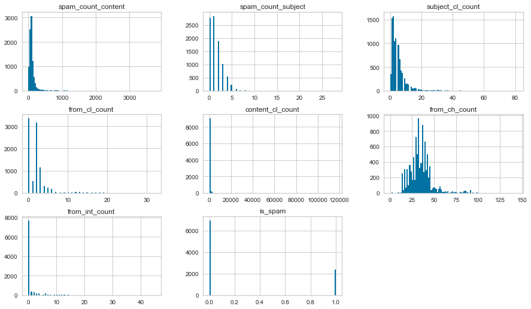

```python
columns = list(data_final.select_dtypes('int64'))
data_final[columns].hist(stacked=False, bins=100, figsize=(15,15), layout=(5,3));
```

```python
data_final.skew()
```

```
spam_count_content     9.379257
spam_count_subject     1.747891
subject_cl_count       3.572663
from_cl_count          3.644891
content_cl_count      31.577371
from_ch_count          1.582716
from_int_count         4.158932
from_dotcom           -0.006855
from_dotedu            5.635035
from_dotus            11.680077
is_spam                1.113557
dtype: float64
```

#### Looking at the mean for both of our spam count columns. Can see that for both the mean is higher for the spam emails (1) than it is for the ham emails (0)

```python
data_final.groupby(['is_spam'])['spam_count_content'].mean()
```

```
is_spam
0    111.692507
1    145.607590
Name: spam_count_content, dtype: float64
```

```python
data_final.groupby(['is_spam'])['spam_count_subject'].mean()
```

```
is_spam
0    1.168300
1    2.224771
Name: spam_count_subject, dtype: float64
```

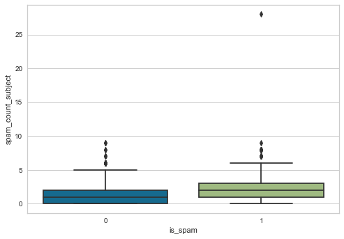

```python
sns.boxplot(x="is_spam", y="spam_count_subject", data=data_final)
```

#### After the outlier was removed, it was easier for us to observe the magnitude of the difference in spam versus non-spam profiles. Spam subject and content word count distribution is higher than non-spam emails.

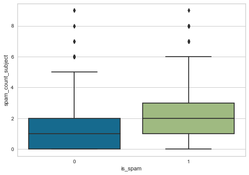

```python
data_final = data_final[data_final['spam_count_subject'] < 20]
sns.boxplot(x="is_spam", y="spam_count_subject", data=data_final)
```

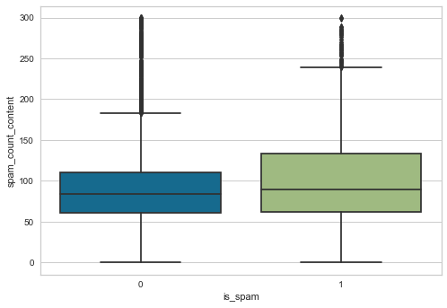

```python
data_final = data_final[data_final['spam_count_content'] < 300]
sns.boxplot(x="is_spam", y="spam_count_content", data=data_final)
```

#### After eliminating the outlier observations from the dataset, the skewness was reduced significantly for those attributes.

```python
data_final.skew()
```

```
spam_count_content     1.288255
spam_count_subject     1.104251
subject_cl_count       3.611340
from_cl_count          3.616751
content_cl_count      31.300991
from_ch_count          1.565681
from_int_count         4.187774
from_dotcom            0.015974
from_dotedu            5.773160
from_dotus            12.483059
is_spam                1.145743
dtype: float64
```

#### The structure of our model entails aggregating the frequency of spam words and email segment word counts such as words in subject line and words in the email body to determine if an email is spam or not.

```python
model_data = data_final.select_dtypes(exclude = 'object')
```

```python
model_data.info()
```

```
<class 'pandas.core.frame.DataFrame'>
Int64Index: 8891 entries, 2 to 2397
Data columns (total 11 columns):
 #   Column              Non-Null Count  Dtype
---  ------              --------------  -----
 0   spam_count_content  8891 non-null   int64
 1   spam_count_subject  8891 non-null   int64
 2   subject_cl_count    8891 non-null   int64
 3   from_cl_count       8891 non-null   int64
 4   content_cl_count    8891 non-null   int64
 5   from_ch_count       8891 non-null   int64
 6   from_int_count      8891 non-null   int64
 7   from_dotcom         8891 non-null   bool
 8   from_dotedu         8891 non-null   bool
 9   from_dotus          8891 non-null   bool
 10  is_spam             8891 non-null   int64
dtypes: bool(3), int64(8)
memory usage: 971.2 KB
```

#### There is distinct separation in the attributes of emails that are spam versus not spam. Our model will leverage these engineered data features to execute the classification task.

```python
fig = px.scatter_3d(model_data, x='spam_count_subject', y='from_ch_count', z='from_cl_count', color='is_spam', title="Separation of Spam")
fig.update_layout(width = 550, height = 550,margin=dict(l=0, r=0, b=0, t=0))
fig.show()
```

[interactive chart not shown]

## Model Building & Evaluation

### KMeans Clustering:

#### KMeans Clustering utilizes a user-specified amount of clusters, k, and uses the calculated means to bucket the observations into their designated cluster.

```python
x = model_data.iloc[:]# 1t for rows and second for columns
x
```

|  | spam_count_content | spam_count_subject | subject_cl_count | from_cl_count | content_cl_count | from_ch_count | from_int_count | from_dotcom | from_dotedu | from_dotus | is_spam |
| --- | --- | --- | --- | --- | --- | --- | --- | --- | --- | --- | --- |
| 2 | 117 | 1 | 4 | 5 | 409 | 39 | 0 | True | False | False | 0 |
| 4 | 134 | 1 | 4 | 5 | 423 | 39 | 0 | True | False | False | 0 |
| 5 | 35 | 1 | 1 | 4 | 51 | 33 | 0 | True | False | False | 0 |
| 8 | 92 | 1 | 4 | 2 | 355 | 23 | 0 | False | True | False | 0 |
| 10 | 70 | 0 | 4 | 0 | 410 | 35 | 4 | False | False | False | 0 |
| ... | ... | ... | ... | ... | ... | ... | ... | ... | ... | ... | ... |
| 2391 | 190 | 3 | 4 | 1 | 340 | 29 | 9 | True | False | False | 1 |
| 2392 | 190 | 3 | 2 | 1 | 339 | 25 | 5 | True | False | False | 1 |
| 2394 | 97 | 2 | 1 | 2 | 137 | 23 | 0 | False | False | False | 1 |
| 2395 | 107 | 3 | 4 | 0 | 134 | 31 | 2 | True | False | False | 1 |
| 2397 | 0 | 0 | 1 | 1 | 0 | 4 | 0 | False | False | False | 1 |

8891 rows × 11 columns

#### Utilizing the elbow method, the optimal number of clusters were identified as 2. There does seem to be a second fold in the elbow at 4 clusters. After the evaluation of the clusters, we determined 2 yielded better separation. We will utilize these cluster labels within our Naive Bayes model and assess the model accuracy to determine their effectiveness.

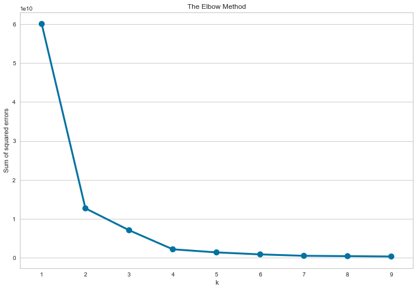

```python
sse = {}
# Fit KMeans and calculate SSE for each k
for k in range(1, 10):
    # Initialize KMeans with k clusters
    kmeans = KMeans(n_clusters=k, random_state=1)
    # Fit KMeans on the normalized dataset
    kmeans.fit(model_data)
    # Assign sum of squared distances to k element of dictionary
    sse[k] = kmeans.inertia_
# Plotting the elbow plot
plt.figure(figsize=(12,8))
plt.title('The Elbow Method')
plt.xlabel('k');
plt.ylabel('Sum of squared errors')
sns.pointplot(x=list(sse.keys()), y=list(sse.values()))
plt.show()
```

```python
kmeans = KMeans(n_clusters=2, algorithm = 'full')
kmeans.fit(x)
```

```
KMeans(algorithm='full', n_clusters=2)
```

#### Cluster the existing data

```python
identified_clusters = kmeans.fit_predict(x)
identified_clusters
```

```
array([0, 0, 0, ..., 0, 0, 0])
```

#### Merge the clusters with the main dataset

```python
data_with_clusters = model_data.copy()
data_with_clusters['Clusters'] = identified_clusters
```

```python
data_with_clusters
```

|  | spam_count_content | spam_count_subject | subject_cl_count | from_cl_count | content_cl_count | from_ch_count | from_int_count | from_dotcom | from_dotedu | from_dotus | is_spam | Clusters |
| --- | --- | --- | --- | --- | --- | --- | --- | --- | --- | --- | --- | --- |
| 2 | 117 | 1 | 4 | 5 | 409 | 39 | 0 | True | False | False | 0 | 0 |
| 4 | 134 | 1 | 4 | 5 | 423 | 39 | 0 | True | False | False | 0 | 0 |
| 5 | 35 | 1 | 1 | 4 | 51 | 33 | 0 | True | False | False | 0 | 0 |
| 8 | 92 | 1 | 4 | 2 | 355 | 23 | 0 | False | True | False | 0 | 0 |
| 10 | 70 | 0 | 4 | 0 | 410 | 35 | 4 | False | False | False | 0 | 0 |
| ... | ... | ... | ... | ... | ... | ... | ... | ... | ... | ... | ... | ... |
| 2391 | 190 | 3 | 4 | 1 | 340 | 29 | 9 | True | False | False | 1 | 0 |
| 2392 | 190 | 3 | 2 | 1 | 339 | 25 | 5 | True | False | False | 1 | 0 |
| 2394 | 97 | 2 | 1 | 2 | 137 | 23 | 0 | False | False | False | 1 | 0 |
| 2395 | 107 | 3 | 4 | 0 | 134 | 31 | 2 | True | False | False | 1 | 0 |
| 2397 | 0 | 0 | 1 | 1 | 0 | 4 | 0 | False | False | False | 1 | 0 |

8891 rows × 12 columns

### Naive Bayes:

#### A classification model that uses a probability-based algorithm that classifies data based on the likelihood of the events occuring within the dataset.

#### Split the data into a 75-25% train-test datasets.

```python
X = data_with_clusters.drop('is_spam', axis=1)
y = data_with_clusters['is_spam']
X_train, X_test,y_train,y_test=train_test_split(X,y,test_size=0.25)
```

#### Based on our EDA, our data displayed behaviors of not having a normal distribution, thus, we chose to implement the Multinomial Naive Bayes model.

```python
clf=MultinomialNB()
```

```python
clf.fit(X_train, y_train)
```

```
MultinomialNB()
```

```python
y_pred=clf.predict(X_test)
```

```python
print('F1 Score: %.3f' % f1_score(y_test, y_pred))
```

```
F1 Score: 0.216
```

```python
predictions = pd.DataFrame(y_pred, columns = ['Predictions'])
```

```python
X_test = X_test.reset_index()
results = pd.merge(X_test, predictions, left_index=True, right_index=True)
```

```python
results.head(25)
```

|  | index | spam_count_content | spam_count_subject | subject_cl_count | from_cl_count | content_cl_count | from_ch_count | from_int_count | from_dotcom | from_dotedu | from_dotus | Clusters | Predictions |
| --- | --- | --- | --- | --- | --- | --- | --- | --- | --- | --- | --- | --- | --- |
| 0 | 127 | 70 | 0 | 2 | 2 | 208 | 32 | 0 | False | False | False | 0 | 0 |
| 1 | 4476 | 39 | 3 | 5 | 0 | 86 | 41 | 0 | False | False | False | 0 | 0 |
| 2 | 6314 | 54 | 1 | 2 | 0 | 147 | 14 | 0 | False | False | False | 0 | 0 |
| 3 | 1271 | 119 | 5 | 7 | 4 | 276 | 33 | 2 | True | False | False | 0 | 0 |
| 4 | 1300 | 133 | 5 | 9 | 6 | 249 | 30 | 0 | True | False | False | 0 | 0 |
| 5 | 431 | 55 | 0 | 3 | 3 | 165 | 32 | 0 | True | False | False | 0 | 0 |
| 6 | 3163 | 78 | 0 | 15 | 3 | 201 | 51 | 0 | False | False | False | 0 | 0 |
| 7 | 5946 | 77 | 0 | 4 | 2 | 262 | 31 | 3 | True | False | False | 0 | 0 |
| 8 | 5783 | 81 | 0 | 2 | 2 | 552 | 37 | 0 | False | False | False | 0 | 1 |
| 9 | 6636 | 34 | 6 | 3 | 0 | 72 | 27 | 0 | True | False | False | 0 | 0 |
| 10 | 1718 | 92 | 5 | 11 | 2 | 200 | 36 | 0 | True | False | False | 0 | 0 |
| 11 | 5546 | 81 | 1 | 1 | 2 | 304 | 33 | 0 | False | False | False | 0 | 0 |
| 12 | 5623 | 89 | 1 | 2 | 6 | 264 | 30 | 0 | False | False | False | 0 | 0 |
| 13 | 3755 | 58 | 1 | 2 | 0 | 87 | 14 | 0 | False | False | False | 0 | 0 |
| 14 | 6821 | 47 | 1 | 7 | 0 | 106 | 32 | 0 | True | False | False | 0 | 0 |
| 15 | 6734 | 32 | 1 | 0 | 0 | 83 | 31 | 0 | True | False | False | 0 | 0 |
| 16 | 1168 | 88 | 1 | 5 | 3 | 201 | 39 | 0 | True | False | False | 0 | 0 |
| 17 | 1368 | 77 | 2 | 2 | 2 | 157 | 33 | 0 | False | False | False | 0 | 0 |
| 18 | 1625 | 103 | 5 | 11 | 1 | 281 | 24 | 0 | False | False | False | 0 | 0 |
| 19 | 5984 | 149 | 0 | 4 | 2 | 298 | 36 | 0 | True | False | False | 0 | 0 |
| 20 | 4827 | 94 | 1 | 3 | 2 | 262 | 36 | 0 | True | False | False | 0 | 0 |
| 21 | 801 | 71 | 1 | 2 | 3 | 157 | 31 | 0 | False | False | False | 0 | 0 |
| 22 | 2980 | 103 | 3 | 0 | 0 | 446 | 21 | 0 | False | False | False | 0 | 1 |
| 23 | 1726 | 91 | 3 | 5 | 1 | 192 | 33 | 6 | True | False | False | 0 | 0 |
| 24 | 1960 | 68 | 1 | 6 | 2 | 182 | 30 | 0 | True | False | False | 0 | 0 |

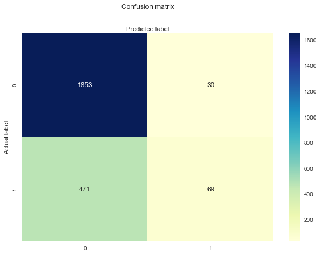

```python
cnf_matrix = confusion_matrix(y_test, y_pred)
class_names=[0,1] # name  of classes
fig, ax = plt.subplots()
tick_marks = np.arange(len(class_names))
plt.xticks(tick_marks, class_names)
plt.yticks(tick_marks, class_names)
# create heatmap
sns.heatmap(pd.DataFrame(cnf_matrix), annot=True, cmap="YlGnBu" ,fmt='g')
ax.xaxis.set_label_position("top")
plt.tight_layout()
plt.title('Confusion matrix', y=1.1)
plt.ylabel('Actual label')
plt.xlabel('Predicted label')
```

## Case Conclusions

#### The top 4 important features were from_dot_edu, our cluster labels from KMeans, from_dot_us, from_dot_com which the domain from which the email is sent should have an impact on the data.

```
FeatureImportances(ax=<AxesSubplot:>, estimator=MultinomialNB(), relative=False)
```

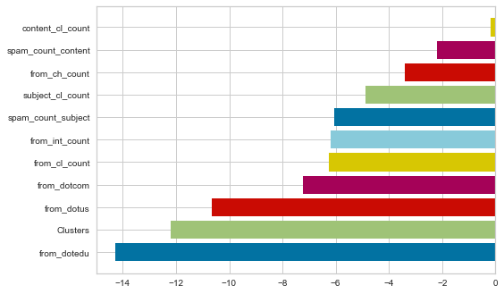

```python
viz = FeatureImportances(clf, relative=False)
viz.fit(X_train, y_train)
```